# Exercício de Análise Fatorial

Aluno(a)

2025-03-04

# 1 **Instruções**

Neste exercício, você aplicará a análise fatorial exploratória (AFE) e confirmatória (AFC) em um conjunto de dados público. Siga os passos indicados e responda às perguntas ao longo do documento.

# 2 **Passo 1: Carregar Pacotes Necessários**

```r
library(psych)       # Análise fatorial exploratória
library(GPArotation) # Métodos de rotação
library(lavaan)      # Análise fatorial confirmatória
library(dplyr)       # Manipulação de dados
```

# 3 **Passo 2: Carregar o Conjunto de Dados**

Utilizaremos o conjunto de dados `bfi` do pacote `psych`, que contém respostas a um questionário de personalidade.

```r
data("bfi", package = "psych")

# Selecionar apenas as variáveis do questionário
bfi_sub <- bfi[, 1:25]

# Visualizar as primeiras observações
dplyr::glimpse(bfi_sub)
```

```
## Rows: 2,800
## Columns: 25
## $ A1 <int> 2, 2, 5, 4, 2, 6, 2, 4, 4, 2, 4, 2, 5, 5, 4, 4, 4, 5, 4, 4, 5, 1, 1…
## $ A2 <int> 4, 4, 4, 4, 3, 6, 5, 3, 3, 5, 4, 5, 5, 5, 5, 3, 6, 5, 4, 4, 4, 6, 5…
## $ A3 <int> 3, 5, 5, 6, 3, 5, 5, 1, 6, 6, 5, 5, 5, 5, 2, 6, 6, 5, 5, 6, 2, 6, 6…
## $ A4 <int> 4, 2, 4, 5, 4, 6, 3, 5, 3, 6, 6, 5, 6, 6, 2, 6, 2, 4, 4, 5, 1, 1, 5…
## $ A5 <int> 4, 5, 4, 5, 5, 5, 5, 1, 3, 5, 5, 5, 4, 6, 1, 3, 5, 5, 3, 5, 2, 5, 6…
## $ C1 <int> 2, 5, 4, 4, 4, 6, 5, 3, 6, 6, 4, 5, 5, 4, 5, 5, 4, 5, 5, 1, 4, 5, 4…
## $ C2 <int> 3, 4, 5, 4, 4, 6, 4, 2, 6, 5, 3, 4, 4, 4, 5, 5, 4, 5, 4, 1, 6, 4, 3…
## $ C3 <int> 3, 4, 4, 3, 5, 6, 4, 4, 3, 6, 5, 5, 3, 4, 5, 5, 4, 5, 5, 1, 5, 4, 2…
## $ C4 <int> 4, 3, 2, 5, 3, 1, 2, 2, 4, 2, 3, 4, 2, 2, 2, 3, 4, 4, 4, 5, 5, 2, 4…
## $ C5 <int> 4, 4, 5, 5, 2, 3, 3, 4, 5, 1, 2, 5, 2, 1, 2, 5, 4, 3, 6, 6, 4, 3, 5…
## $ E1 <int> 3, 1, 2, 5, 2, 2, 4, 3, 5, 2, 1, 3, 3, 2, 3, 1, 1, 2, 1, 1, 3, 1, 2…
## $ E2 <int> 3, 1, 4, 3, 2, 1, 3, 6, 3, 2, 3, 3, 3, 2, 4, 1, 2, 2, 2, 1, 3, 2, 1…
## $ E3 <int> 3, 6, 4, 4, 5, 6, 4, 4, NA, 4, 2, 4, 3, 4, 3, 6, 5, 4, 4, 4, 5, 4, …
## $ E4 <int> 4, 4, 4, 4, 4, 5, 5, 2, 4, 5, 5, 5, 2, 6, 6, 6, 5, 6, 5, 5, 5, 3, 5…
## $ E5 <int> 4, 3, 5, 4, 5, 6, 5, 1, 3, 5, 4, 4, 4, 5, 5, 4, 5, 6, 5, 6, 4, 4, 2…
## $ N1 <int> 3, 3, 4, 2, 2, 3, 1, 6, 5, 5, 3, 4, 1, 1, 2, 4, 4, 6, 5, 5, 1, 2, 2…
## $ N2 <int> 4, 3, 5, 5, 3, 5, 2, 3, 5, 5, 3, 5, 2, 1, 4, 5, 4, 5, 6, 5, 3, 5, 2…
## $ N3 <int> 2, 3, 4, 2, 4, 2, 2, 2, 2, 5, 4, 3, 2, 1, 2, 4, 4, 5, 5, 5, 3, 5, 2…
## $ N4 <int> 2, 5, 2, 4, 4, 2, 1, 6, 3, 2, 2, 2, 2, 2, 2, 5, 4, 4, 5, 1, 2, 4, 2…
## $ N5 <int> 3, 5, 3, 1, 3, 3, 1, 4, 3, 4, 3, NA, 2, 1, 3, 5, 5, 4, 2, 1, 1, 6, …
## $ O1 <int> 3, 4, 4, 3, 3, 4, 5, 3, 6, 5, 5, 4, 4, 5, 5, 6, 5, 5, 4, 4, 6, 5, 6…
## $ O2 <int> 6, 2, 2, 3, 3, 3, 2, 2, 6, 1, 3, 6, 2, 3, 2, 6, 1, 1, 2, 1, 1, 1, 1…
## $ O3 <int> 3, 4, 5, 4, 4, 5, 5, 4, 6, 5, 5, 4, 4, 4, 5, 6, 5, 4, 2, 5, 3, 6, 5…
## $ O4 <int> 4, 3, 5, 3, 3, 6, 6, 5, 6, 5, 6, 5, 5, 4, 5, 3, 6, 5, 4, 3, 2, 6, 5…
## $ O5 <int> 3, 3, 2, 5, 3, 1, 1, 3, 1, 2, 3, 4, 2, 4, 5, 2, 3, 4, 2, 2, 4, 2, 2…
```

**Pergunta 1:** Quais são as escalas de medida das variáveis do conjunto de dados? Por que isso é importante na análise fatorial?

# 4 **Passo 3: Verificar os Pressupostos para AFE**

```r
# Teste de Kaiser-Meyer-Olkin
KMO(bfi_sub)
```

```
## Kaiser-Meyer-Olkin factor adequacy
## Call: KMO(r = bfi_sub)
## Overall MSA =  0.85
## MSA for each item =
##   A1   A2   A3   A4   A5   C1   C2   C3   C4   C5   E1   E2   E3   E4   E5   N1
## 0.74 0.84 0.87 0.87 0.90 0.83 0.79 0.85 0.82 0.86 0.83 0.88 0.89 0.87 0.89 0.78
##   N2   N3   N4   N5   O1   O2   O3   O4   O5
## 0.78 0.86 0.88 0.86 0.85 0.78 0.84 0.76 0.76
```

```r
# Teste de Bartlett
cortest.bartlett(bfi_sub)
```

```
## R was not square, finding R from data
```

```
## $chisq
## [1] 20163.79
##
## $p.value
## [1] 0
##
## $df
## [1] 300
```

Se os resultados indicarem que os dados não são adequados para a análise fatorial, o que poderia ser feito?

**Pergunta 2:** Interprete os resultados dos testes KMO e Bartlett. O que indicam sobre a adequação dos dados?

# 5 **Passo 4: Realizar a Análise Fatorial Exploratória (AFE)**

```r
# Realizar AFE com extração de máxima verossimilhança e rotação Varimax
fa_result <- fa(bfi_sub, nfactors = 5, rotate = "varimax", fm = "ml")

# Exibir os resultados
print(fa_result, digits = 3)
```

```
## Factor Analysis using method =  ml
## Call: fa(r = bfi_sub, nfactors = 5, rotate = "varimax", fm = "ml")
## Standardized loadings (pattern matrix) based upon correlation matrix
##       ML2    ML1    ML3    ML5    ML4    h2    u2  com
## A1  0.113  0.037  0.002 -0.364 -0.058 0.150 0.850 1.27
## A2  0.038  0.179  0.151  0.584  0.065 0.401 0.599 1.37
## A3  0.019  0.274  0.107  0.648  0.067 0.511 0.489 1.44
## A4 -0.052  0.154  0.233  0.441 -0.102 0.286 0.714 1.97
## A5 -0.113  0.340  0.078  0.585  0.080 0.483 0.517 1.79
## C1 -0.002  0.041  0.523  0.053  0.207 0.321 0.679 1.34
## C2  0.076 -0.001  0.621  0.137  0.130 0.427 0.573 1.22
## C3 -0.020  0.006  0.547  0.132  0.004 0.317 0.683 1.12
## C4  0.230 -0.086 -0.629 -0.021 -0.094 0.465 0.535 1.36
## C5  0.276 -0.187 -0.565 -0.061  0.033 0.435 0.565 1.74
## E1  0.033 -0.587  0.038 -0.123 -0.079 0.369 0.631 1.14
## E2  0.231 -0.679 -0.094 -0.149 -0.054 0.548 0.452 1.39
## E3  0.014  0.482  0.063  0.336  0.301 0.441 0.559 2.58
## E4 -0.104  0.601  0.084  0.370 -0.045 0.519 0.481 1.80
## E5  0.048  0.486  0.314  0.125  0.228 0.405 0.595 2.40
## N1  0.800  0.094 -0.037 -0.218 -0.084 0.705 0.295 1.21
## N2  0.782  0.052 -0.024 -0.203 -0.025 0.657 0.343 1.15
## N3  0.716 -0.078 -0.081 -0.018  0.004 0.525 0.475 1.05
## N4  0.558 -0.356 -0.187 -0.012  0.063 0.478 0.522 1.99
## N5  0.522 -0.183 -0.048  0.107 -0.135 0.338 0.662 1.51
## O1 -0.003  0.180  0.105  0.096  0.521 0.324 0.676 1.40
## O2  0.174 -0.011 -0.113  0.112 -0.434 0.244 0.756 1.62
## O3  0.016  0.259  0.070  0.165  0.611 0.473 0.527 1.54
## O4  0.216 -0.220 -0.024  0.145  0.375 0.257 0.743 2.67
## O5  0.085 -0.010 -0.074  0.013 -0.511 0.274 0.726 1.10
##
##                         ML2   ML1   ML3   ML5   ML4
## SS loadings           2.668 2.254 1.967 1.947 1.518
## Proportion Var        0.107 0.090 0.079 0.078 0.061
## Cumulative Var        0.107 0.197 0.276 0.353 0.414
## Proportion Explained  0.258 0.218 0.190 0.188 0.147
## Cumulative Proportion 0.258 0.475 0.665 0.853 1.000
##
## Mean item complexity =  1.6
## Test of the hypothesis that 5 factors are sufficient.
##
## df null model =  300  with the objective function =  7.228 with Chi Square =  20163.79
## df of  the model are 185  and the objective function was  0.628
##
## The root mean square of the residuals (RMSR) is  0.03
## The df corrected root mean square of the residuals is  0.038
##
## The harmonic n.obs is  2762 with the empirical chi square  1474.696  with prob <  1.29e-199
## The total n.obs was  2800  with Likelihood Chi Square =  1749.883  with prob <  1.39e-252
##
## Tucker Lewis Index of factoring reliability =  0.8721
## RMSEA index =  0.055  and the 90 % confidence intervals are  0.0526 0.0573
## BIC =  281.469
## Fit based upon off diagonal values = 0.979
## Measures of factor score adequacy
##                                                     ML2   ML1   ML3   ML5   ML4
## Correlation of (regression) scores with factors   0.927 0.867 0.857 0.845 0.824
## Multiple R square of scores with factors          0.859 0.752 0.734 0.714 0.679
## Minimum correlation of possible factor scores     0.718 0.504 0.468 0.428 0.358
```

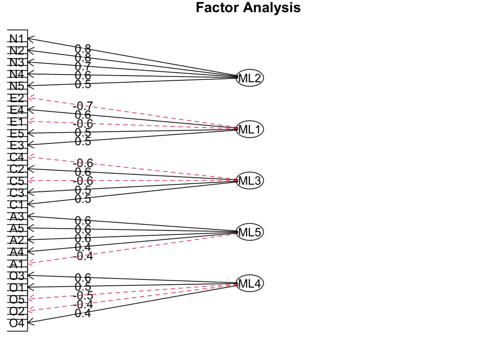

```r
fa.diagram(fa_result)  # Visualização gráfica
```

**Pergunta 3:** Como interpretar a matriz de cargas fatoriais? Quais variáveis possuem maior peso em cada fator?

# 6 **Passo 5: Realizar a Análise Fatorial Confirmatória (AFC)**

Agora, definiremos um modelo baseado na estrutura obtida na AFE e o testaremos com AFC.

```r
# Verificar os nomes das variáveis
colnames(bfi_sub)
```

```
##  [1] "A1" "A2" "A3" "A4" "A5" "C1" "C2" "C3" "C4" "C5" "E1" "E2" "E3" "E4" "E5"
## [16] "N1" "N2" "N3" "N4" "N5" "O1" "O2" "O3" "O4" "O5"
```

```r
# Definir modelo baseado nos fatores obtidos, substituindo índices por nomes reais
modelo_afc <- '
F1 =~ A1 + A2 + A3 + A4 + A5
F2 =~ C1 + C2 + C3 + C4 + C5
'

# Ajustar modelo
ajuste <- cfa(modelo_afc, data = bfi_sub)
summary(ajuste, fit.measures = TRUE, standardized = TRUE)
```

```
## lavaan 0.6-19 ended normally after 40 iterations
##
##   Estimator                                         ML
##   Optimization method                           NLMINB
##   Number of model parameters                        21
##
##                                                   Used       Total
##   Number of observations                          2632        2800
##
## Model Test User Model:
##
##   Test statistic                               503.340
##   Degrees of freedom                                34
##   P-value (Chi-square)                           0.000
##
## Model Test Baseline Model:
##
##   Test statistic                              5469.721
##   Degrees of freedom                                45
##   P-value                                        0.000
##
## User Model versus Baseline Model:
##
##   Comparative Fit Index (CFI)                    0.913
##   Tucker-Lewis Index (TLI)                       0.885
##
## Loglikelihood and Information Criteria:
##
##   Loglikelihood user model (H0)             -42637.052
##   Loglikelihood unrestricted model (H1)     -42385.382
##
##   Akaike (AIC)                               85316.104
##   Bayesian (BIC)                             85439.489
##   Sample-size adjusted Bayesian (SABIC)      85372.766
##
## Root Mean Square Error of Approximation:
##
##   RMSEA                                          0.072
##   90 Percent confidence interval - lower         0.067
##   90 Percent confidence interval - upper         0.078
```

[output cut: 32 more lines]

```
##
## Variances:
##                    Estimate  Std.Err  z-value  P(>|z|)   Std.lv  Std.all
##    .A1                1.712    0.050   34.527    0.000    1.712    0.863
##    .A2                0.776    0.029   27.044    0.000    0.776    0.558
##    .A3                0.746    0.035   21.514    0.000    0.746    0.437
##    .A4                1.656    0.051   32.497    0.000    1.656    0.748
##    .A5                0.963    0.034   28.708    0.000    0.963    0.603
##    .C1                1.065    0.034   30.911    0.000    1.065    0.697
##    .C2                1.078    0.038   28.597    0.000    1.078    0.618
##    .C3                1.131    0.037   30.481    0.000    1.131    0.681
##    .C4                1.027    0.040   25.825    0.000    1.027    0.544
##    .C5                1.707    0.058   29.465    0.000    1.707    0.646
##     F1                0.271    0.032    8.611    0.000    1.000    1.000
##     F2                0.463    0.035   13.160    0.000    1.000    1.000
```

**Pergunta 4:** Quais são os principais indicadores de ajuste do modelo AFC? Como interpretá-los?

# 7 **Conclusão**

Após realizar a AFE e AFC, escreva um parágrafo resumindo suas principais descobertas e interpretações.

Este exercício ajudará a consolidar sua compreensão sobre a análise fatorial aplicada a dados reais.